# User Guide

[figure not shown]

### *Introduction*

[Plotly](https://plot.ly) lets you collaboratively make and share beautiful, web-based plots. You can collaboratively use R, ggplot2, and a GUI, along with MATLAB, Python, and Excel. Here are some of your charting options:

[figure not shown]

This Notebook will cover:

- World Bank plotting with ggplot2
- Facets with ggplot2
- Collaboration and flexibility with Plotly
- Bar charts in ggplot2 and Plotly
- Scatter plots
- Embedding in web pages
- Native capabilities, roadmap, and getting in touch
- IPython installation and use

## I. World Bank plotting with ggplot2

Let's plot! You can copy and paste any of these examples into your R environment to follow along. Head over to our getting started page for more on installation.

```r
local({r <- getOption("repos")  # You'll want to select the CRAN mirror you like.
       r["CRAN"] <- "http://cran.r-project.org"
       options(repos=r)
})
```

Use Plotly's public sandbox (username "ggplot2examples" shown below), or [sign-up](https://plot.ly/ssu) for an account. Let's make our first plot with a ggplot2 plot from [the World Bank website](http://blogs.worldbank.org/opendata/accessing-world-bank-data-apis-python-r-ruby-stata) .

[figure not shown]

We run the script, call `py$ggplotly()` , and re-draw the ggplot2 figure in Plotly.

```r
install.packages("devtools")  # Windows users install Rtools
library("devtools")
install_github("ropensci/plotly")  # Plotly is part of the super cool rOpenSci

library(plotly)  # Load libraries we’ll be using
library(reshape)

py <- plotly("ggplot2examples", "3gazttckd7")  # Open Plotly connection

library(WDI)  # Now we’ll make the plot from the blog post

dat = WDI(indicator='NY.GNP.PCAP.CD', country=c('CL','HU','UY'), start=1960, end=2012)
# Grab GNI per capita data for Chile, Hungary and Uruguay

wb <- ggplot(dat, aes(year, NY.GNP.PCAP.CD, color=country)) + geom_line()
+     xlab('Year') + ylab('GDI per capita (Atlas Method USD)')
+     labs(title <- "GNI Per Capita ($USD Atlas Method)")

py$ggplotly(wb)  # Call the ggplotly conversion function
```

That produces an error, but that's ok: Plotly still graphs it and grabs the data. Grab the response from https://plot.ly/~ggplot2examples, make an iframe function, and add the URL for your graph to your iframe.

```r
library(IRdisplay)
plotly_iframe <- function(url) {
    # Set width and height from options or default square
    w <- "750"
    h <- "600"
    html <- paste("<center><iframe height=\"", h, "\" id=\"igraph\" scrolling=\"no\" seamless=\"seamless\"\n\t\t\t\tsrc=\"",
        url, "\" width=\"", w, "\" frameBorder=\"0\"></iframe></center>", sep="")
    return(html)
}
```

```r
display_html(plotly_iframe("https://plot.ly/~ggplot2examples/98"))
```

[interactive chart not shown]

The data is stored with the plot. I forked the data and shared it: https://plot.ly/~MattSundquist/1343.

Below, you'll find graphs made with the same data using Plotly's Python API, matplotlib, and our web app. You can find all of these in [another Notebook](http://nbviewer.ipython.org/gist/msund/61cdbd5b22c103fffb84) .

[figure not shown]

Take-away: *You can edit the same graph and add data from any language or our web GUI* . Collaboration and technical flexibility between languages, the GUI, and users of all types is what Plotly is all about.

Just add '.r' to the end of Plotly URLS (e.g. https://plot.ly/~MattSundquist/1339.r) and you can see the plot object in Plotly's declarative syntax for R.

Here are your other options for the plot we just made:

https://plot.ly/~ggplot2examples/98.py

https://plot.ly/~ggplot2examples/98.m

https://plot.ly/~ggplot2examples/98.jl

https://plot.ly/~ggplot2examples/98.js

https://plot.ly/~ggplot2examples/98.json

https://plot.ly/~ggplot2examples/98.svg

https://plot.ly/~ggplot2examples/98.png

https://plot.ly/~ggplot2examples/98.pdf

[figure not shown]

```r
display_html(plotly_iframe("https://plot.ly/~MattSundquist/1339"))
```

[interactive chart not shown]

```r
str(dat)  # Once published, you can list all objects and their attributes
```

```
'data.frame':	159 obs. of  4 variables:
 $ iso2c         : chr  "CL" "CL" "CL" "CL" ...
 $ country       : chr  "Chile" "Chile" "Chile" "Chile" ...
 $ NY.GNP.PCAP.CD: num  14290 12290 10730 9940 10030 ...
 $ year          : num  2012 2011 2010 2009 2008 ...
```

```r
py <- plotly("ggplot2examples", "3gazttckd7")  # Or you can use Plotly to call any figure
figure <- py$get_figure("MattSundquist", 1339)
str(figure)
```

```
List of 2
 $ layout:List of 25
  ..$ boxmode      : chr "overlay"
  ..$ paper_bgcolor: chr "#fff"
  ..$ height       : num 547
  ..$ titlefont    :List of 3
  .. ..$ color : chr ""
  .. ..$ family: chr ""
  .. ..$ size  : num 0
  ..$ hovermode    : chr "x"
  ..$ font         :List of 3
  .. ..$ color : chr "rgb(67, 67, 67)"
  .. ..$ family: chr "'Open sans', verdana, arial, sans-serif"
  .. ..$ size  : num 12
  ..$ autosize     : logi TRUE
  ..$ title        : chr "GNI Per Capita ($USD Atlas Method)"
  ..$ plot_bgcolor : chr "rgba(245, 247, 247, 0.7)"
  ..$ dragmode     : chr "zoom"
  ..$ smith        : logi FALSE
  ..$ width        : num 1304
  ..$ bargap       : num 0.2
  ..$ xaxis        :List of 33
  .. ..$ showexponent  : chr "all"
  .. ..$ showticklabels: logi TRUE
  .. ..$ domain        : num [1:2] 0 1
  .. ..$ gridcolor     : chr "rgb(255, 255, 255)"
  .. ..$ linecolor     : chr "#444"
  .. ..$ mirror        : logi FALSE
  .. ..$ autotick      : logi TRUE
  .. ..$ linewidth     : num 1
  .. ..$ nticks        : num 0
  .. ..$ title         : chr "year"
  .. ..$ ticks         : chr ""
  .. ..$ rangemode     : chr "normal"
  .. ..$ overlaying    : logi FALSE
  .. ..$ zeroline      : logi FALSE
  .. ..$ type          : chr "linear"
  .. ..$ autorange     : logi TRUE
  .. ..$ zerolinewidth : num 1
  .. ..$ ticklen       : num 5
```

[output cut: 311 more lines]

```
  .. .. ..$ : num 7690
  .. .. ..$ : num 8520
  .. .. ..$ : num 10110
  .. .. ..$ : num 11700
  .. .. ..$ : num 13580
  .. ..$ mode    : chr "lines"
  .. ..$ marker  :List of 1
  .. .. ..$ line: Named list()
  .. ..$ x       : num [1:53] 1960 1961 1962 1963 1964 ...
  .. ..$ line    :List of 3
  .. .. ..$ color: chr "rgb(44, 160, 44)"
  .. .. ..$ width: num 4
  .. .. ..$ shape: chr "spline"
  .. ..$ type    : chr "scatter"
  .. ..$ error_y : Named list()
```

```r
figure$data[]  # or call the data so you can analyze it or bring data from any plot into your R environment
```

```
[[1]]
[[1]]$textfont
named list()

[[1]]$error_x
named list()

[[1]]$name
[1] "Chile"

[[1]]$uid
[1] "5485f4"

[[1]]$text
NULL

[[1]]$y
[[1]]$y[[1]]
NULL

[[1]]$y[[2]]
NULL

[[1]]$y[[3]]
[1] 600

[[1]]$y[[4]]
[1] 640

[[1]]$y[[5]]
[1] 660

[[1]]$y[[6]]
[1] 650

[[1]]$y[[7]]
[1] 740

[[1]]$y[[8]]
[1] 760
```

[output cut: 570 more lines]

```
[[3]]$line$color
[1] "rgb(44, 160, 44)"

[[3]]$line$width
[1] 4

[[3]]$line$shape
[1] "spline"


[[3]]$type
[1] "scatter"

[[3]]$error_y
named list()
```

## Sidebar: Benefits of collaboration and a language-agnostic platform

" *[The Secret History](http://www.amazon.com/The-Secret-History-Donna-Tartt/dp/1400031702)* " mentions the *Iliad's* notion of "light shining from a dead star." Graphs are like that: a brief flash of light and brilliance from a dead dataset. Why is the data dead? Because we'll never see or access the data used in plots, especially if it's in another language. Or the data is buried in an email, desktop folder, or file. Plotly solves that problem by saving graphs with their related data, scripts, and JSON structure.

Keeping your data and code around has other benefits; [one study](http://www.smithsonianmag.com/science-nature/the-vast-majority-of-raw-data-from-old-scientific-studies-may-now-be-missing-180948067/?no-ist) in current biology found that over 90 percent of data from papers published over the past 20 years was not available. Making your graph in Plotly ensures your data, plot, revision history, and comments will always be together and accessible. Sharing one unified entity can also be useful for publication or sharing on [figshare](http://blog.plot.ly/post/84750214457/figshare-graphs-in-plotly) .

## II. Facets with ggplot2

Facets in ggplot2 are awesome. Try zooming in on one of the subplots here by clicking and dragging; check out how plots with a shared axis will also zoom for you.

```r
p <- ggplot(diamonds, aes(x=carat, y=price))
p <- p + geom_point(aes(colour=clarity)) + facet_grid(cut ~ color, margins=TRUE)
py$ggplotly(p)
```

```r
display_html(plotly_iframe("https://plot.ly/~MattSundquist/1630"))  # edited in GUI
```

[interactive chart not shown]

## III. Collaboration and flexibility with Plotly

People often come to a visualization with data then decide on the best visualization. As Homer Adkins once quiped:

> Basic research is like shooting an arrow into the air, and where it lands, painting a target.

Once you have your graph in Plotly you don't need to re-code your graph (though you can). Plotly detects which graph types fit with your data. Explore like a boss. Plotly gives you comprehensive, delightful collaboration online and from our APIs. You can also use Plotly for your data exploration and analysis, collaborating with users at any level to make 3D plots and more.

[figure not shown]

## IV. Bar charts in ggplot2 and Plotly

Let's try a [wealth distribution chart](http://mhermans.net/wealth-dist-areas.html) .

```r
require(reshape2)
require(plyr)
require(spdep)
require(igraph)
require(ggplot2)
require(RColorBrewer)
```

```r
wealth.dist <- structure(
  list(
    CA = c(0.054, 0.442, 0.349, 0.155),  # 2005, family
    FR = c(0.040, 0.440, 0.278, 0.242),  # 2010, adult
    IE = c(0.050, 0.390, 0.330, 0.230),  # 2001, household
    IT = c(0.115, 0.462, 0.301, 0.122),  # 2008, household
    GB = c(0.092, 0.465, 0.318, 0.125),  # 2008, household
    US = c(0.025, 0.265, 0.372, 0.338),  # 2007, family
    BE = c(0.135, 0.373, 0.300, 0.197)), # 1994, family
  .Names = c("CA", "FR", "IE", "IT", "GB", "US", "BE"),
  row.names = c("Bottom 50%", "Mid 40%", "Top 9%", "Elite 1%"),
  class = "data.frame")

wealth.dist <- wealth.dist[,order(wealth.dist[4,])] # order by share 1%

t(wealth.dist*100) # print table
```

```
   Bottom 50% Mid 40% Top 9% Elite 1%
IT       11.5    46.2   30.1     12.2
GB        9.2    46.5   31.8     12.5
CA        5.4    44.2   34.9     15.5
BE       13.5    37.3   30.0     19.7
IE        5.0    39.0   33.0     23.0
FR        4.0    44.0   27.8     24.2
US        2.5    26.5   37.2     33.8
```

[output not shown]

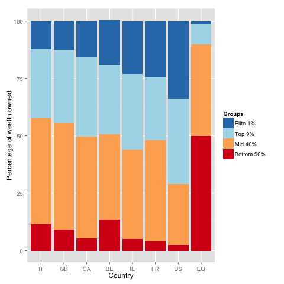

```r
wealth.dist$EQ <- c(0.5, 0.4, 0.09, 0.01)  # add perfectly equal country

# restack data (one rown per combination)
d <- melt(t(wealth.dist))
names(d) <- c("country", "group", "value")
d$group <- factor(d$group, levels = row.names(wealth.dist))
d$country <- factor(d$country, levels = names(wealth.dist))

# plot distributions in stacked barchart
q <- ggplot(d, aes(country, value * 100, fill = group)) +
    geom_bar(stat = "identity")
q <- q + scale_fill_brewer(
    palette = "RdYlBu",
    guide = guide_legend(reverse = TRUE, title = "Groups"))
q <- q + opts(title = "National wealth ownership")
q + scale_x_discrete(name = "Country") +
    scale_y_continuous(name = "Percentage of wealth owned")
py$ggplotly()
```

```r
display_html(plotly_iframe("https://plot.ly/~ggplot2examples/220"))
```

[interactive chart not shown]

## V. Scatter plots

Let's try a scatter, straight from the ggplot2 docs.

```r
dsamp <- diamonds[sample(nrow(diamonds), 1000), ]
d <- qplot(carat, price, data=dsamp, colour=clarity)
py$ggplotly()
```

```r
display_html(plotly_iframe("https://plot.ly/~ggplot2examples/42"))
```

[interactive chart not shown]

```r
display_html(plotly_iframe("https://plot.ly/~MattSundquist/1511"))  # then hide a few series and add a pair of fits.
```

[interactive chart not shown]

## VI. Embedding in web pages

Do you use Shiny, the web framework for R? Check out our tutorial for using Plotly in a Shiny app !

Your interactive plots can be embedded in iframes in web pages, blogs, Notebooks, and RPubs (see an [rOpenSci post](http://ropensci.org/blog/2014/04/17/plotly/) and accompanying source for instructions on embedding). Plotly is like your combined Instagram and GitHub for plots and data.

Embed your interactive graphs in blogs or websites with this snippet:

```
<iframe src="https://plot.ly/~MattSundquist/1334/650/550" width="650" height=550" frameBorder="0" seamless="seamless" scrolling="no"></iframe>
```

Here's how it looks in the Washington Post:

[figure not shown]

## VII. Aspirations, roadmap, and getting in touch

CP Snow, in " *[The Two Cultures](http://en.wikipedia.org/wiki/The_Two_Cultures)* " argues that the divide between sciences and humanities is a vast hindrance to societal advancement and solving problems. Plotly is about solving this problem: making technical tools and plotting available and artistic. Artistry meets technical firepower. Our hope is that by making the platform flexible and encompassing of all technologies and skill-levels, we can create a collaborative space for plotting at any level. Also, pretty graphs are just downright delightful.

You can use ggplot2 to make bar, line, and scatter charts. More to come. You can then use Plotly's other tools to make those plus bubble, polar, contour, heatmaps, histograms, boxplots, 3D graphs, and streaming graphs. Or, use Plotly and $LaTeX$ . Head over to [our gallery](https://plot.ly/r) to see more examples.

Get in touch at feedback at plot dot ly, on GitHub , or [@plotlygraphs] (twitter.com/plotlygraphs).

## VIII. IPython installation and use

This post is based on an [IPython Notebook running R](http://nbviewer.ipython.org/gist/msund/403910de45e282d658fa) . IPython is part of [Project Jupyter](https://speakerdeck.com/fperez/project-jupyter) , a language agnostic interactive development environment. If you're *reading* here:

> nbviewer.ipython.org/gist/msund/403910de45e282d658fa

you're seeing how *coding* using an IPython Notebook looks, minus the tools. You get Markdown, a GUI, reproducibility, and a beautiful Notebook (NB) that's easy to publish by posting it on GitHub. Here's what I'm looking at right now:

[figure not shown]

You can install the IPython NB, R kernel, matplotlib, and ggplot2, from Docker. Docker is a rather mind-blowing Linux container project: “An open source project to pack, ship and run any application as a lightweight container.” You can build an application, ship it through Docker, and someone else can easily install it and the necessary dependencies. Here’s one for the R kernel, IPython, and matplotlib:

https://github.com/alexander-daniel/IPython-matplotlylib-Dockerfile

And another for the R kernel:

https://github.com/alexander-daniel/IPython-R-Kernel-Plotly-Docker